# Linear Regression

Audrey Baguette

Workshop Lead

Alex Diaz-Papkovich

Original Material

Adrien Osakwe

Original Material

September 24, 2025

# Loading libraries

```r
library(tidyverse)
```

# Verifying the dataset

Let’s take the iris data set, and check if the petal length and width follow a linear correlation

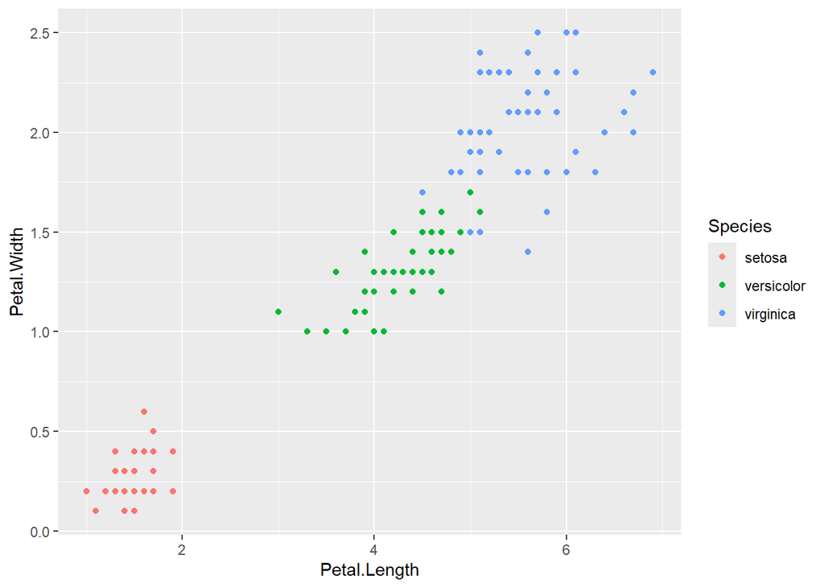

```r
ggplot(iris) + geom_point(aes(Petal.Length, Petal.Width, col = Species))
```

```r
cor(iris$Petal.Length, iris$Petal.Width)
```

```
## [1] 0.9628654
```

The data seems to be linearly correlated. The species have different ranges of sizes, but they seem to all follow the same trend.

# Fitting with MLE

## 1- Estimating beta1

$$\hat{\beta_1} =
\frac{\sum^{N}_{i=1}(x_{i} - \bar{x})(y_{i} -
\bar{y})}{\sum_{i=1}^{N}(x_{i} - \bar{x})^{2}} =
\frac{SS_{xy}}{SS_{xx}}$$

```r
mean_x = mean(iris$Petal.Length)
mean_y = mean(iris$Petal.Width)
numerator = sum((iris$Petal.Length - mean_x) * (iris$Petal.Width - mean_y))
denominator = sum((iris$Petal.Length - mean_x)**2)
beta1 = numerator / denominator
```

## 2- Estimating beta0

$$\hat{\beta_0} = \bar{y} -
\hat{\beta_{1}}\bar{x}$$

```r
beta0 = mean_y - beta1*mean_x
```

## 3- Visualize the regression

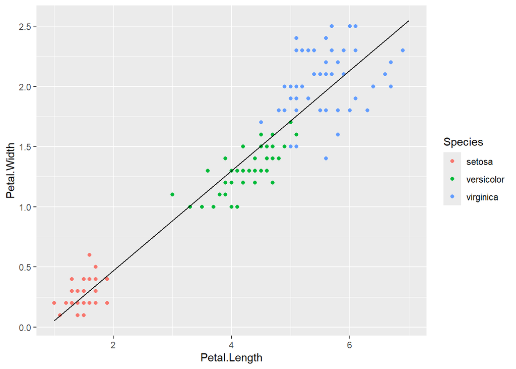

```r
regression_df = data.frame(x = 1:7, y = beta0+c(1:7)*beta1)
ggplot(iris) + geom_point(aes(Petal.Length, Petal.Width, col = Species)) +
            geom_line(aes(x, y), data = regression_df)
```

# Build-in linear regression

lm is the build-in regression function

```r
linear_model <- lm(Petal.Width ~ Petal.Length, data = iris)
summary(linear_model)
```

```
##
## Call:
## lm(formula = Petal.Width ~ Petal.Length, data = iris)
##
## Residuals:
##      Min       1Q   Median       3Q      Max
## -0.56515 -0.12358 -0.01898  0.13288  0.64272
##
## Coefficients:
##               Estimate Std. Error t value Pr(>|t|)
## (Intercept)  -0.363076   0.039762  -9.131  4.7e-16 ***
## Petal.Length  0.415755   0.009582  43.387  < 2e-16 ***
## ---
## Signif. codes:  0 '***' 0.001 '**' 0.01 '*' 0.05 '.' 0.1 ' ' 1
##
## Residual standard error: 0.2065 on 148 degrees of freedom
## Multiple R-squared:  0.9271, Adjusted R-squared:  0.9266
## F-statistic:  1882 on 1 and 148 DF,  p-value: < 2.2e-16
```

Plot the results to compare with the MLE

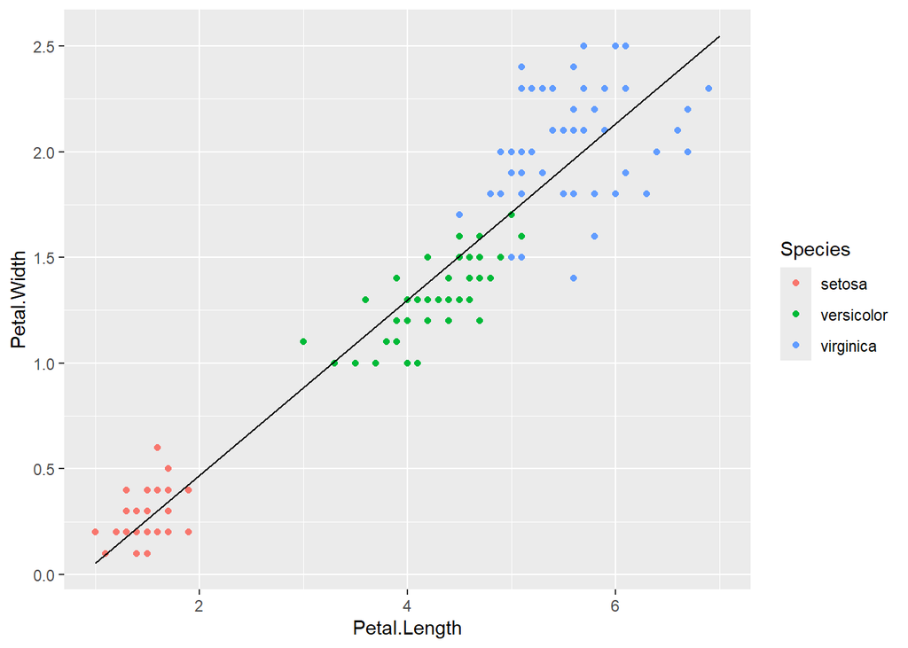

```r
regression_df2 = data.frame(x = 1:7, y = linear_model$coefficients[1]+c(1:7)*linear_model$coefficients[2])
ggplot(iris) + geom_point(aes(Petal.Length, Petal.Width, col = Species)) +
  geom_line(aes(x, y), data = regression_df2)
```

# Predicting results

Say we remove the versicolor species during model construction, can we predict the Petal Width in function of its Length?

1- We remove the versicolor data and compute the model

```r
iris_subset <- iris %>% filter(Species != 'versicolor')
iris_model <- lm(Petal.Width ~ Petal.Length, data = iris_subset)
```

2- We extract the versicolor Petal Length

```r
versicolor_p <- iris %>% filter(Species == 'versicolor') %>%
                          mutate(Predicted_pw = iris_model$coefficients[1] + Petal.Length*iris_model$coefficients[2])
```

Alternatively

```r
predict.lm(iris_model, versicolor_p, type = 'response')
```

```
##         1         2         3         4         5         6         7         8
## 1.6429911 1.5579967 1.7279854 1.3455110 1.6004939 1.5579967 1.6429911 1.0480309
##         9        10        11        12        13        14        15        16
## 1.6004939 1.3030138 1.1330252 1.4305053 1.3455110 1.6429911 1.1755224 1.5154996
##        17        18        19        20        21        22        23        24
## 1.5579967 1.3880081 1.5579967 1.3030138 1.6854882 1.3455110 1.7279854 1.6429911
##        25        26        27        28        29        30        31        32
## 1.4730024 1.5154996 1.6854882 1.7704825 1.5579967 1.1330252 1.2605167 1.2180195
##        33        34        35        36        37        38        39        40
## 1.3030138 1.8129797 1.5579967 1.5579967 1.6429911 1.5154996 1.3880081 1.3455110
##        41        42        43        44        45        46        47        48
## 1.5154996 1.6004939 1.3455110 1.0480309 1.4305053 1.4305053 1.4305053 1.4730024
##        49        50
## 0.9205394 1.3880081
```

3- Plot the results

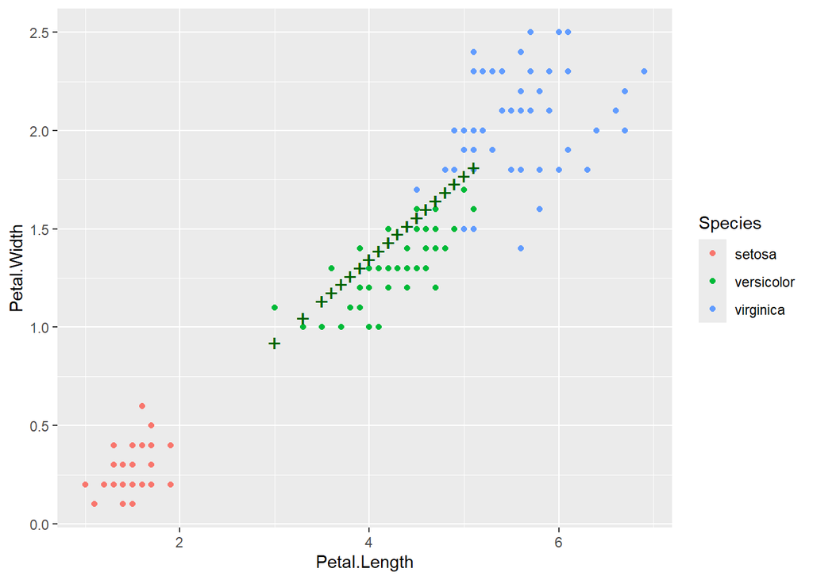

```r
ggplot(iris) + geom_point(aes(Petal.Length, Petal.Width, col = Species)) +
  geom_point(aes(Petal.Length, Predicted_pw), data = versicolor_p, color = 'darkgreen', shape = '+', size = 5)
```

4- Compute the MSE

```r
MSE = mean((versicolor_p$Petal.Width - versicolor_p$Predicted_pw)**2)
print(MSE)
```

```
## [1] 0.03341702
```

# Using multiple variables

What if we also use the Sepal values to predict the Petal Width?

1- We compute the model after removal of versicolor

```r
iris_model2 <- lm(Petal.Width ~ Petal.Length + Sepal.Length + Sepal.Width, data = iris_subset)
```

2- We extract the versicolor Petal Length

```r
versicolor_p2 <- iris %>% filter(Species == 'versicolor') %>%
  mutate(Predicted_pw = iris_model2$coefficients[1] +
                        Petal.Length*iris_model2$coefficients[2] +
                        Sepal.Length*iris_model2$coefficients[3] +
                        Sepal.Width*iris_model2$coefficients[4])
```

3- Plot the results

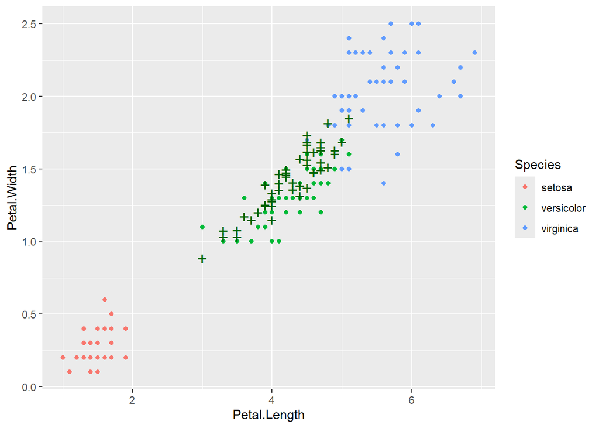

```r
ggplot(iris) + geom_point(aes(Petal.Length, Petal.Width, col = Species)) +
  geom_point(aes(Petal.Length, Predicted_pw), data = versicolor_p2, color = 'darkgreen', shape = '+', size = 5)
```

4- Compute the MSE

```r
MSE2 = mean((versicolor_p2$Petal.Width - versicolor_p2$Predicted_pw)**2)
print(MSE2)
```

```
## [1] 0.02571336
```

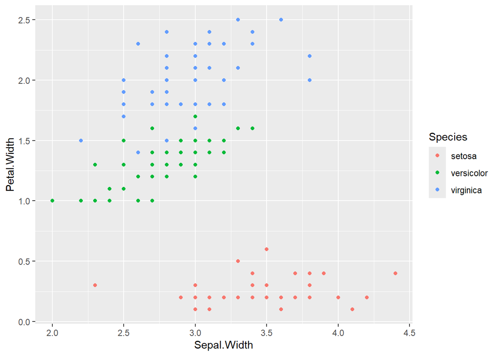

```r
ggplot(iris) + geom_point(aes(Sepal.Width, Petal.Width, col = Species))
```

```r
cor(iris$Sepal.Width, iris$Petal.Width)
```

```
## [1] -0.3661259
```

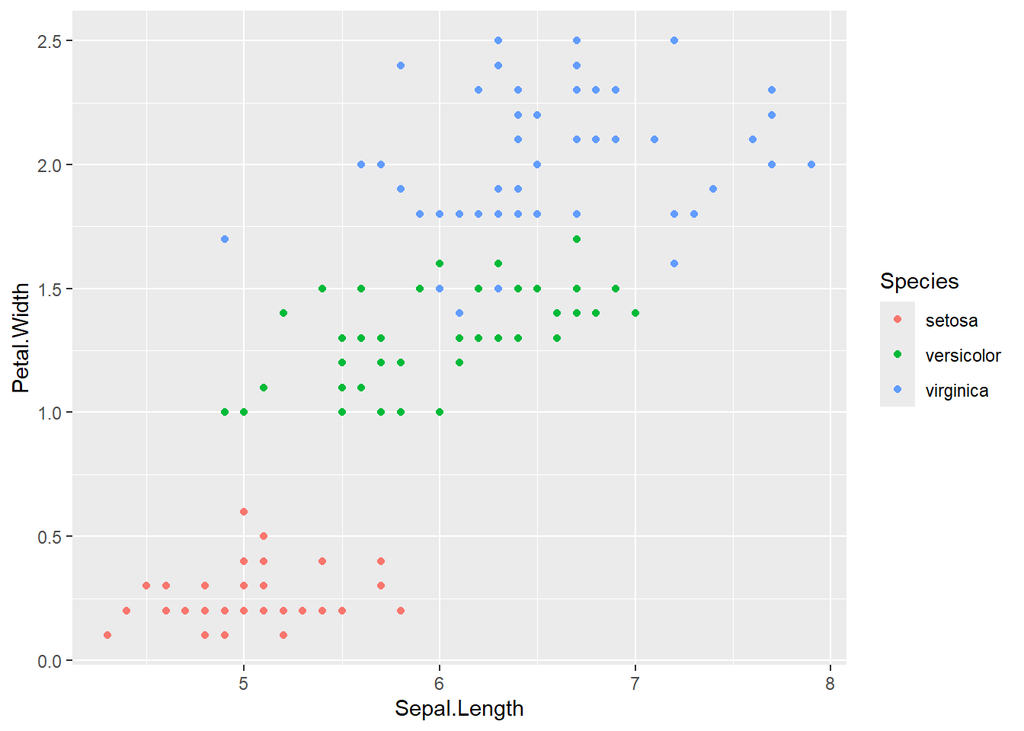

```r
ggplot(iris) + geom_point(aes(Sepal.Length, Petal.Width, col = Species))
```

```r
cor(iris$Sepal.Length, iris$Petal.Width)
```

```
## [1] 0.8179411
```

Quick test with only the Petal Length and Sepal Length

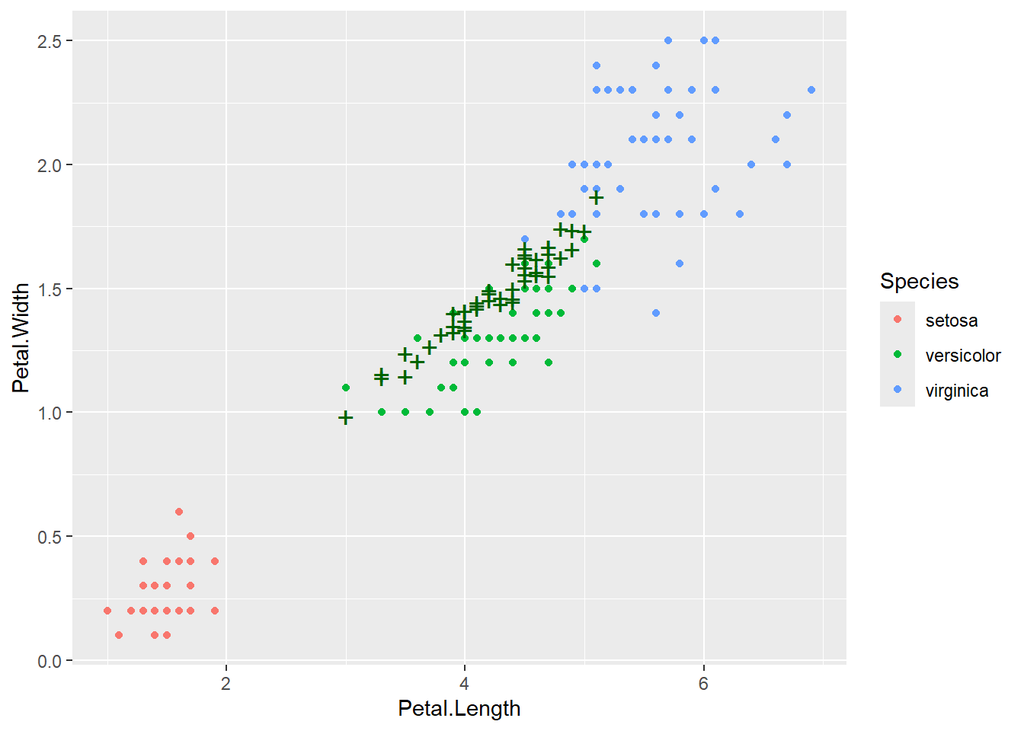

```r
iris_model3 <- lm(Petal.Width ~ Petal.Length + Sepal.Length, data = iris_subset)
versicolor_p3 <- iris %>% filter(Species == 'versicolor') %>%
  mutate(Predicted_pw = iris_model3$coefficients[1] +
                        Petal.Length*iris_model3$coefficients[2] +
                        Sepal.Length*iris_model3$coefficients[3])
MSE3 = mean((versicolor_p3$Petal.Width - versicolor_p3$Predicted_pw)**2)
ggplot(iris) + geom_point(aes(Petal.Length, Petal.Width, col = Species)) +
  geom_point(aes(Petal.Length, Predicted_pw), data = versicolor_p3, color = 'darkgreen', shape = '+', size = 5)
```

```r
print(MSE3)
```

```
## [1] 0.03871654
```

This is the worst MSE of the 3, possibly because of overfitting.

# Hands-on

Create your own linear model

Using mtcars, find the best linear model to predict the miles per gallon (mpg) Use the first 2/3 of the data as training data for the model and the last third as test data

```r
mtcars_train <- mtcars[1:22,]
mtcars_test <- mtcars[23:32,]
```